### Nonlinear Problems in Finance (MATHGR5400), Columbia University, Spring 2019

# Homework I

### Due Date: 11:55 PM Sunday, Feb 24, 2019

You should turn in the notebook at Columbia CourseWorks website

Please comment your code properly.

Before you turn in the notebook, press the "Run all cells" button in the toolbar, and make sure all the calculation results and graphs are produced correctly in a reasonable time frame, and then save the notebook.

```python
%matplotlib inline
import itertools
import scipy
import math
import matplotlib.pyplot as plt
import numpy as np
from scipy.special import laguerre
from scipy.interpolate import interp1d
from scipy.stats import norm
plt.rc('figure', figsize=(6, 5))
plt.rc('axes', grid=True, xmargin=0, ymargin=0, autolimit_mode='round_numbers')
```

# 1. Conditional Expection and Least Square Regression

Let $X$ and $Y$ be two random variables. The conditional expectation $\mathbb{E}\left[Y|X\right]$ is a function $f^{\ast}$ of $X$ that best approximates $Y$ in the least square sense, i.e.,

$$\mathbb{E}\left[Y|X\right]=f^{\ast}(X)\quad\text{and}\quad\mathbb{E}\left[\left|Y-f^{\ast}(X)\right|^2\right]\leq\mathbb{E}\left[\left|Y-f(X)\right|^2\right]\text{ for any function }f\text{ of }X$$

Let us define the random variables $X$ and $Y$ by $$ g(x) = x \frac{1 + x}{1 + x^2}, \qquad X \sim \mathcal{N}(0, 1), \quad Y = g(X) + \varepsilon $$ where $\varepsilon \sim \mathcal{N}(0, 1/16)$ is independent of $X$.

Note that $\mathbb{E}\left[\left.Y\right|X\right] = \mathbb{E}\left[\left.g(X)+\varepsilon\right|X\right] = g(X)+\mathbb{E}\left[\left.\varepsilon\right|X\right] = g(X)$.

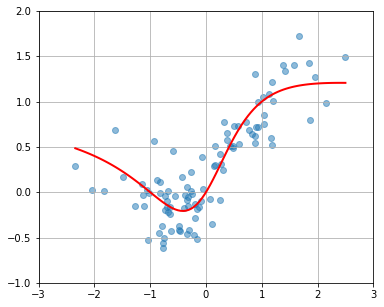

```python
# Plot a random sample of the joint distribution and the
# theoretical conditional expectation of Y wrt X.

def g(x):
    return x*(1+x)/(1+x**2)

n = 100
sigma = 0.25
X = np.random.randn(n)
Y = g(X) + sigma * np.random.randn(n)

fig, ax = plt.subplots()
ax.scatter(X, Y, alpha=0.5)
x = np.linspace(X.min(), X.max(), 101)
ax.plot(x, g(x), 'r', linewidth=2)
```

## Parametric regression

The conditional expection $\mathbb{E}\left[\left.Y\right|X\right]$ is approximated by a linear combination of a set of given *basis* functions $\{f_i(X)\}_{0\leq i\leq n}$, i.e.,

$$\mathbb{E}\left[Y|X\right]\approx \beta_0^*f_0(X)+\cdots+\beta_n^*f_n(X)$$

where

$$\mathbb{E}\left[\left(Y-\beta_0^*f_0(X)-\cdots-\beta_n^*f_n(X)\right)^2\right] = \min_{\beta_1,\ldots,\beta_n}\mathbb{E}\left[\left(Y-\beta_0f_0(X)-\cdots-\beta_nf_n(X)\right)^2\right]$$

Given $N$ observations $\left((x_1,y_1),\ldots,(x_N, y_N)\right)$ of $X$ and $Y$, one finds the optimal parameters $\beta_i$ by solving the least square problem $\min_\beta\|A\beta-y\|_2$, where $$A=\begin{bmatrix}f_0(x_1) & \cdots & f_n(x_1)\\ \vdots & \ddots & \vdots \\ f_0(x_N) & \cdots & f_n(x_N)\end{bmatrix}\quad \text{and}\quad y=\begin{bmatrix}y_1\\ \vdots \\ y_N\end{bmatrix}$$

The numpy routine **numpy.linalg.lstsq** can be used to solve such linear least square problems.

### Polynomials

The basis functions are taken to be power functions $f_i(X)=X^{i}$, that is $\mathbb{E}\left[Y|X\right]$ is a polynomial of $X$. The numpy routine **numpy.polyfit** is a convenient way to obtain the least square polynomial fit.

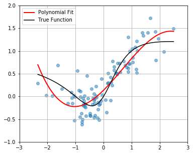

```python
# Fit a polynomial of degree 3 to the sample points (X, Y)
p = np.polyfit(X, Y, deg=3)
fig, ax = plt.subplots()
ax.scatter(X, Y, alpha=0.5)
ax.plot(x, np.polyval(p, x), 'r', lw=2, label='Polynomial Fit')
ax.plot(x, g(x), 'k', label='True Function')
ax.legend(loc=0)
```

### Laguerre Polynomials

The *Laguerre* polynomials are defined by

$$L_n(x)=\frac{1}{n!}\left(\frac{d}{dx}-1\right)^nx^n.$$

In particular, we have

$$L_0(x)=1,\quad L_1(x)=-x+1,\quad L_2(x)=\frac{1}{2}\left(x^2-4x+2\right),\quad\cdots$$

They are orthogonal polynomials with respect to the inner product $\langle f, g\rangle=\int_0^{\infty}f(x)g(x)e^{-x}dx$. Therefore we will be actually using the weighted version

$$\tilde{L}_n(x)=e^{-x/2}L_n(x)$$

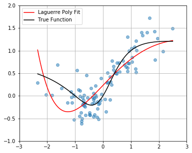

```python
L = lambda x, i: laguerre(i)(x)*np.exp(-x/2)
A = np.vstack((L(X, 0), L(X, 1), L(X, 2))).T
p = np.linalg.lstsq(A, Y, rcond=None)[0]
fig, ax = plt.subplots()
ax.scatter(X, Y, alpha=0.5)
ax.plot(x, L(x,0)*p[0]+L(x,1)*p[1]+L(x,2)*p[2], 'r', label='Laguerre Poly Fit')
ax.plot(x, g(x), 'k', label='True Function')
ax.legend(loc=0)
```

### Piecewise Linear Regression

```python
def pwlinear_basis(xknots):
    """Basis that represent a piecewise linear function with given knots"""
    fs = [lambda x: np.ones_like(x, dtype=np.float), lambda x: x-xknots[0]]
    fs.extend([lambda x, a=xknots[i]: np.maximum(x-a, 0) for i in range(len(xknots))])
    return fs

def pwlinear_fit(xdata, ydata, xknots):
    """Fit a piecewise linear function with xknots to xdata and ydata"""
    fs = pwlinear_basis(xknots)
    A = np.vstack([f(xdata) for f in fs]).T
    ps = np.linalg.lstsq(A, ydata, rcond=None)[0]
    return ps, fs
```

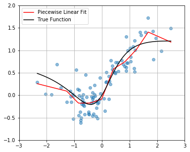

```python
xknots = np.linspace(np.percentile(X, 5), np.percentile(X, 95), 8)
# fs = pwlinear_basis(xknots)
ps, fs = pwlinear_fit(X, Y, xknots)
fig, ax = plt.subplots()
ax.scatter(X, Y, alpha=0.5)
ax.plot(x, sum([f(x)*p for (f, p) in zip(fs, ps)]), 'r', label='Piecewise Linear Fit')
ax.plot(x, g(x), 'k', label='True Function')
ax.legend(loc=0)
```

## Nonparametric regression

### Nadaraya-Watson Kernel regression (Local Weighted Average)

Here, no parametric form is assumed for $\mathbb{E}[Y|X]$. Instead, local averages of $Y$ values are computed, given the value of $X$:

$$\mathbb{E}\left[Y|X\right]\approx\frac{\sum_{i=1}^NK_h(x-x_i)y_i}{\sum_{i=1}^NK_h(x-x_i)}$$

where $K$ is a kernel function and $K_h(x)=K(x/h)$, $h$ is the *bandwidth*. $K_h$ approximates the Dirac mass at zero.

### Local Linear Regression

The locally weighted linear regression solves a separate weighted least squares problem at each target point $x$,

$$\hat{\alpha},\hat{\beta} = \text{argmin}_{\alpha,\beta}\sum_{i=1}^NK_h(x-x_i)\left[y_i-\alpha-\beta x_i\right]^2$$

which yields an estimate $\hat{\alpha}+\hat{\beta}x$. Note that $\hat{\alpha}$ and $\hat{\beta}$ depend on $x$. The locally-weighted averages can be badly biased on the boundaries. This bias can be removed by local linear regression to the first order.

**Note.** To speed up, we often perform the local regression only at a selection of points and then use interpolation/extrapolation to evaluate at other target points.

```python
# Non-parametric regression function

def gauss_kern(x):
    """Gaussian kernel function"""
    return np.exp(-x**2/2)

def kern_reg(x, xdata, ydata, bandwidth, kern=gauss_kern):
    """Nadaraya-Watson Kernel Regression (Locally weighted average)

    Parameters
    ----------
    x: array_like, one-dimensional
        The x-coordinates of the target points
    xdata: array_like
        The x-coordinates of the data points.
    ydata: array_like
        The y-coordinates of the data points.
    bandwidth: positive scalar
        Bandwidth of the kernel
    kern: callable
        kernel function
    """
    weights = kern((xdata[:, np.newaxis] - x) / bandwidth)
    return np.sum(weights * ydata[:, np.newaxis], axis=0) / np.sum(weights, axis=0)


def ll_reg(x, xdata, ydata, bandwidth, kern=gauss_kern):
    """Local Linear Regression

    Parameters
    ----------
    x: array_like, one-dimensional
        The x-coordinates of the target points
    xdata: array_like
        The x-coordinates of the data points.
    ydata: array_like
        The y-coordinates of the data points.
    bandwidth: positive scalar
        Bandwidth of the kernel
    kern: callable
        kernel function
    """

    def func(xx):
        weights = np.sqrt(kern((xdata-xx)/bandwidth))
        b = ydata*weights
        A = np.vstack((np.ones_like(xdata), xdata-xx)).T*weights[:, np.newaxis]
        yy, _ = np.linalg.lstsq(A, b, rcond=None)[0]
        return yy

    return np.vectorize(func)(x)
```

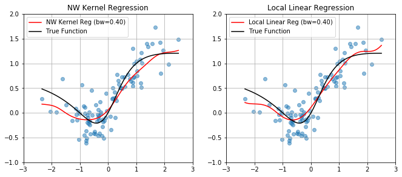

```python
fig, axs = plt.subplots(1,2, figsize=(11, 4.5))
bw_silverman = (4/(3*len(X)))**0.2*np.std(X)
axs[0].plot(x, kern_reg(x, X, Y, bw_silverman, gauss_kern), color='r', label='NW Kernel Reg (bw={:.2f})'.format(bw_silverman))
axs[0].set_title('NW Kernel Regression')
axs[1].plot(x, ll_reg(x, X, Y, bw_silverman, gauss_kern), color='r', label='Local Linear Reg (bw={:.2f})'.format(bw_silverman))
axs[1].set_title('Local Linear Regression')
for ax in axs:
    ax.scatter(X, Y, alpha=0.5)
    ax.plot(x, g(x), 'k', label='True Function')
    ax.legend(loc=0)
```

## Questions

**Question 1.1**. (Parametric regression) In general, increasing the number of basis functions in the regression gives us more flexibility to better fit the data. However, having too many parameters in the model oftentimes leads to overfitting, which usually has poor predictive performance and is over-sensitive to small noise in the data. To observe the overftting phenomenon, in polynomial fit and Laguerre polynomial fit, try to use different degrees of the polynomials; in piecewise-linear regression, try to use difference number of knots. Then reproduce the scatter plot with fitted regression function. Compare and comment on the results.

#### Q1

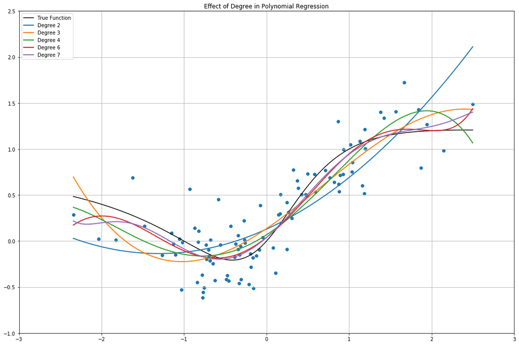

```python
#the following code uses a for loop to plot polynomial fits of different degrees

fig, ax = plt.subplots(figsize=(18, 12))
ax.scatter(X, Y, alpha=1)
ax.plot(x, g(x), 'k', label='True Function')

for i in [2,3,4,6,7]:
    p = np.polyfit(X, Y, deg=i)
    ax.plot(x, np.polyval(p, x), lw=2, label='Degree {} '.format(i))

ax.legend(loc=0)
ax.set_title("Effect of Degree in Polynomial Regression")
```

With the polynomial basis functions, I tested degrees of 2,3,4,6, and 7.

- The 6th and 7th degree fits were typically very similar and matched the true fit relatively well in the center of the data range, but at the extreme ends, the curves have a lot of overfitting to data points that are relatively far from the true fit. The oscillatory phenomenom (Runge's phenomenom) present in higher order polynomials at the ends of the interpolation range are seen to an extent for most of the random X vectors I generated and tested.
- The 2nd and 3rd degree polynomials do not exhibit overfitting to the spurious data points, but also have the downside of not being able to fulfill as many constraints as the higher degree polynomials. The shape of the curves are too general to follow the varying curvature of the true function.
- The 4th degree polynomial used usually led to the best match the true function, yet still shows some overfitting and large deviations at the boundaries. Although none of the polynomial fits will be perfect, this curve showed strong accuracy in the region where the data points are mostly concentrated.
- It is clear from the progression of the polynomial curves, that as the degree increases, the overfitting to spurious data points, increased number of inflection points, and oscillatory phenomenom lead to large deviations from the true function, but depending on the particular data points in the vector X, the higher degree polynomials may not have large deviations at the extreme ends of the data range.

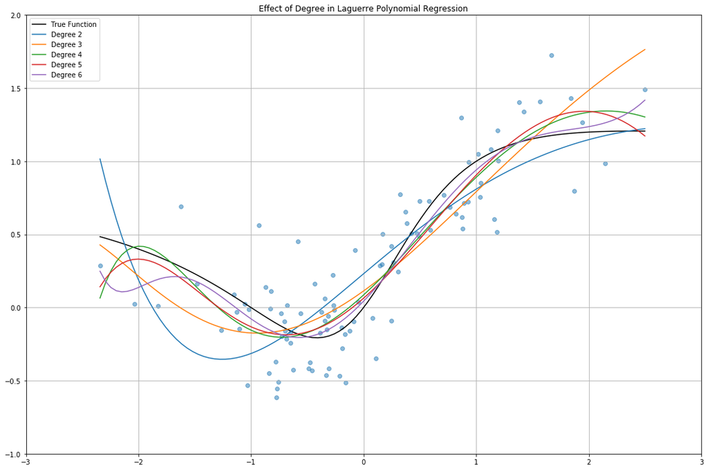

```python
#the following code tests degrees for the Laguerre polynomial

L = lambda x, i: laguerre(i)(x)*np.exp(-x/2)


fig, ax = plt.subplots(figsize=(18, 12))
ax.scatter(X, Y, alpha=0.5)
ax.plot(x, g(x), 'k', label='True Function')

#create a list of Laguerre polynomial terms up to the max desired degree, this list will be used later to generate
#the Laguerre polynomial for each degree
lists = [L(X,i) for i in range(7)]

#for the range of desired degrees, perform the least squares minimization and plot the resulting Laguerre fit
for i in range(2,7):
    A = np.vstack(lists[:i+1]).T
    p = np.linalg.lstsq(A, Y, rcond=None)[0]
    ax.plot(x,sum([L(x,z)*p for (z, p) in zip(np.arange(0,i+1), p)]), label='Degree {}'.format(i))

ax.legend(loc=0)
ax.set_title("Effect of Degree in Laguerre Polynomial Regression")
```

With the Laguerre polynomial basis functions, I tested degrees of 2,3,4,5 and 6.

- The 5th and 6th degree fits are very similar and match the true fit relatively well in the center of the data range, but at the extreme ends, the curves have overfitting, typical of higher order polynomials at ends of the interpolation range. In many cases of the random vector X, the 6th degree polynomial, exhibited a huge deviation from the true function at the ends of the data range, as the spurious points it attempts to fit and higher degree terms and derivatives lead to a large error relative to the true function. This could be resolved using a piecewise polynomial fit towards the ends of the data range.
- The 2nd degree Laguerre polynomial does not exhibit overfitting, but has overall large deviations from the true function. As in the polynomial basis functions case, the low order polynomial is not able to fulfill as many constraints as the higher degree polynomials, and thus curve is inaccurate.
- The 3rd and 4th degree Laguerre polynomials seem to best match the true function, but show some moderate overfitting at the boundaries. The curves usually had no major deviation from the true function, but for the fourth degree polynomial there were many cases where there was a great deal of overfitting at the boundaries.
- In general the Laguerre polynomial and regular polynomial curves for the same degrees were very similar. The shapes were nearly identical in many cases, but there was a consistent trend that the Laguerre Polynomials had larger deviations/overfitting. This may be due to the extra terms in the Laguerre Polynomial expansions.

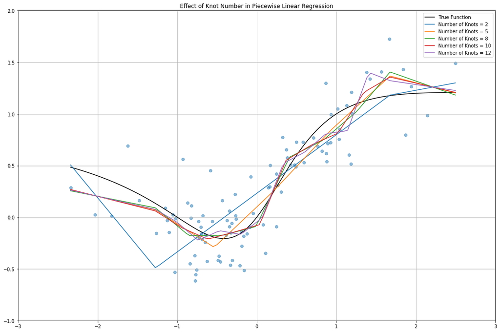

```python
fig, ax = plt.subplots(figsize=(18, 12))
ax.scatter(X, Y, alpha=0.5)
ax.plot(x, g(x), 'k', label='True Function')

for k in [2,5,8,10,12]:
    xknots = np.linspace(np.percentile(X, 5), np.percentile(X, 95), k)
    ps, fs = pwlinear_fit(X, Y, xknots)
    ax.plot(x, sum([f(x)*p for (f, p) in zip(fs, ps)]), label='Number of Knots = {}'.format(k))

ax.legend(loc=0)
ax.set_title("Effect of Knot Number in Piecewise Linear Regression")
```

For the piecewise linear regression I tested using 2, 5, 8, 10, and 12 knots, all equally spaced from the 5th to 95th percentile of the input data, just like in the example given.

- The regression with two knots, although with moderate deviations at most locations due to inflexibility of the curve, was able to generally follow the true function's shape. The performance seems in line with the lower order polynomial fits, but the piecewise linear regression also could have fit the curve even better if the knots were chosen closer to the true function's extrema.
- In the regresion with five knots, the knots were well dispersed throughout the data range and thus were able to capture the general shape of the function extremely accurately compared to the polynomial regressions. Especially in ranges where many data points appeared, the linear regressions were able to find fits very close to the true function. In the regions where the data was more dispersed, the linear regression led to fits that were less accurate, but still close to the true function.
- In using 8, 10, and 12 knots, the curves resulting from the regression looked very similar. As the number of knots increased, the more there was 'oscillatory' behavior in the overall curve, as the piece by piece linear regressions began to overfit to data due to the smaller ranges in which the regressions occurred. This meant that using 5 knots was the best choice in most situations, rather than using higher values of knots. This could be remedied by choosing knots that were not equidistant, but this would not be practical in many situations since we can only make this judgement after observing the form of the true function. The choice of equally spaced knots would be a good standard choice when performing most regressions as it would not 'overweight' any certain region of the data.
- In general, the piecewise linear regression performed the best out of the 3 types of regressions tested, due to the special characteristic of having knots being placed throughout the data range, and therefore the ability to capture local phenomena without leading to compromises in the rest of the curve. This is not possible in the polynomial curves, where the polynomials must be considered as a whole. For example there are limits on the number of inflection points possible in a polynomial curve of a certain, and when attempting to increase the degree of the polynomial to create a better fit, this often leads to oscillatory behavior and overfitting.

**Question 1.2**. For nonparametric regression,

- Try different bandwidth values in the kernel regression. Reproduce the scatter plot with fitted regression function. Compare and comment on the results. For what values of the bandwidth do we observe overfitting? For what values of the bandwidth do we observe a poor fit?
- Try to use different kernels, for example $$K(x)=(x+1)^2(1-x)^2\quad\text{for }-1\leq x\leq 1\quad\text{and}\quad0\quad\text{ elsewhere.}$$ Which has more impact: the bandwidth $h$ or the kernel $K$?

#### Q1.2

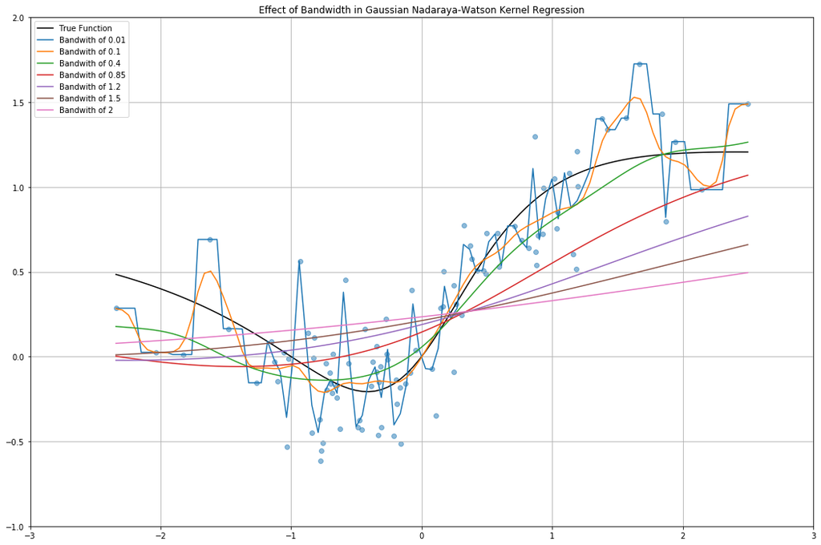

```python
fig, ax = plt.subplots(figsize=(18,12))
ax.scatter(X, Y, alpha=0.5)
ax.plot(x, g(x), 'k', label='True Function')
bw_silverman = (4/(3*len(X)))**0.2*np.std(X)

for bw in [0.01, 0.1, .4, .85, 1.2, 1.5, 2]:
    ax.plot(x, kern_reg(x, X, Y, bw, gauss_kern),  label='Bandwith of {}'.format(bw))

ax.legend(loc=0)
ax.set_title("Effect of Bandwidth in Gaussian Nadaraya-Watson Kernel Regression")
```

In the Nadaraya-Watson Kernel Regression, I tested bandwidths of 0.01, 0.1, .4, .85, 1.2, 1.5, and 2.

- For the lowest bandwiths of 0.01 and 0.1, there was extreme overfitting in the curves. This is because the low bandwith means the kernel functions are effectively being 'shrunk' to act in a smaller area and thus being more sensitive to local datapoints. This shows that at lower bandwidths there is very high variance but low bias, as the curves are specialized to this present data set without making many assumptions about the general shape of the true function.
- In the high bandwidth regions of 0.85, 1.2, 1.5, and 2, the curves are underfitting and extremely general. The curves are tending towards linearity as the bandwidth gets higher and higher, and this can be explained from the high bandwidth which effectively increases the standard deviation of the gaussian kernel function. The estimated probability distributions are therefore much more spread out and lead to smoother curves in both the kernel density estimation and in the kernel regression.
- The bandwidth of 0.4, very close to the Silverman rule of thumb bandwidth, led to the best results. This curve had some regions of larger deviations, but was generally able to follow the shape of the curve very well. This shows that the bias-variance tradeoff in regression is very important, especially in kernel regression, where the bandwidths can be easily modified to totally change the effectiveness of a particular regression. A balance between bias and variance is necessary to avoid overfitting and underfitting, and minimizing the mean integrated square error is able to perform this task well.
- In general the kernel regression at the 0.4 bandwidth performed well compared to the polynomial, laguerre polynomial, and piecewise linear regressions. Using 5 equally spaced knots in the piecewise linear regression might be preferred to this 0.4 bandwidth kernel regression as it more closely follows the true function in the range where the data points are most heavily distributed.

## Kernels

```python
def Example(x):
    """Example kernel function"""
    def func(x):
        if (-1.0 <= x <= 1): return ((x+1.0)**2.0) * ((1.0-x)**2.0)
        else: return 0.0
    return np.vectorize(func)(x)

def Modified_Example(x):
    """Example kernel function with terms added rather than multiplied"""
    def func(x):
        if (-1.0 <= x <= 1): return ((x+1.0)**2.0) + ((1.0-x)**2.0)
        else: return 0.0
    return np.vectorize(func)(x)

def Quartic(x):
    """Quartic kernel function"""
    def func(x):
        if (-1.0 <= x <= 1): return (15.0/16.0)*((1.0 + x)**2.0)*((1.0 - x)**2.0)
        else: return 0
    return np.vectorize(func)(x)

def Epanechnikov(x):
    """Epanechnikov( kernel function"""
    def func(x):
        if (-1.0 <= x <= 1): return (3.0/4.0) *((1.0 - (x**2.0)))
        else: return 0
    return np.vectorize(func)(x)

def Gaussian(x):
    """Gaussian kernel function"""
    return np.exp(-x**2/2)

def Triweight(x):
    """Triweight kernel function"""
    def func(x):
        if (-1.0 <= x <= 1): return (35.0/32.0)*((1.0 - (x**2.0))**3.0)
        else: return 0
    return np.vectorize(func)(x)
```

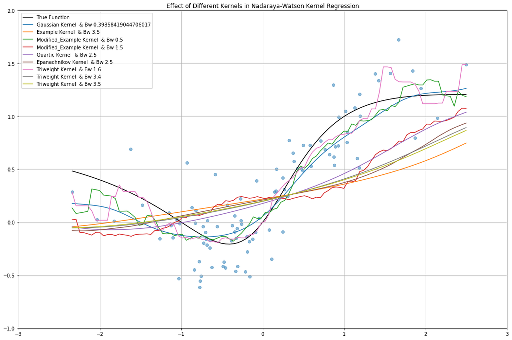

```python
fig, ax = plt.subplots(figsize=(18,12))
ax.scatter(X, Y, alpha=0.5)
ax.plot(x, g(x), 'k', label='True Function')
bw_silverman = (4/(3*len(X)))**0.2*np.std(X)

#list of bandwidths to try for each kernel, matching the order of arguments in the list of kernels below
lists = [[bw_silverman], [3.5], [0.5,1.5], [2.5], [2.5], [1.6, 3.4, 3.5]]
list_of_kern = [Gaussian, Example, Modified_Example, Quartic, Epanechnikov, Triweight]
#dictionary to create link between a kernel and its bandwidths
d1 = dict(zip(list_of_kern, lists))

#for loop runs through the kernels and the corresponding bandwidths and performs the kernel regression
for kernel in list_of_kern:
    for bw in d1[kernel]:
        ax.plot(x, kern_reg(x, X, Y, bw, kernel),  label='{} Kernel  & Bw {}'.format(kernel.__name__, bw))

ax.legend(loc=0)
ax.set_title("Effect of Different Kernels in Nadaraya-Watson Kernel Regression")
```

I tried using the following Kernels: Gaussian, the kernel in the problem, the kernel in the problem with the terms added $K(x)=(x+1)^2 + (1-x)^2$, the Quartic kernel, $K(x) = \frac{15}{16}(1+x)^2(1-x)^2$, Epanechnikov kernel, $K(x) = \frac{3}{4}(1-x^2)$, and the Triweight kernel $K(x) = \frac{35}{32}(1-x^2)^3$. All of the kernels except for the Gaussian kernel had bounded support (on $-1\leq x\leq 1$). For each of these kernels I tried several different bandwidth values, but display only some of the interesting/relevant bandwidths.

- The Gaussian kernel as explained before, performs best around the $~0.4$ bandwidth range, due to the optimization of the bias-variance tradeoff. Compared to the other kernels, the Gaussian kernel is much smoother as well, due to not having a bounded support, and thus the kernel functions sum up with less jumps.
- The kernel given in the problem had the issue that for lower bandwidths, the denominator in the kernel regression, $\sum_{i=1}^NK_h(x-x_i)$, was $0$. This meant that the division in the NW regression led to NaN for certain target points, and therefore discontinuities in the graph. In most cases, for a given bandwidth, NaN was the value for all target points and thus nothing at all was plotted. As the bandwidth was greatly increased, to around 3.5, the NaN issue was resolved, but by this point the curve was greatly underfit to the data. The higher bandwidths has too much bias and could not specialize to the data effectively.
- The modified kernel I used where the terms were added instead, performed better than the unmodified kernel, due to the removal of the NaN issue. Again, bandwidths around $~0.5$ were better, while higher bandwidths led to too much bias, although the curves were also smoother. The $0.5$ bandwidth curve was very jagged, and although the jaggedness followed the general shape of the curve, there would be large variations in predicted values for inputs in a small range.
- The quartic and epanechnikov kernels had the same issue as the kernel given in the problem. For smaller bandwidths, there were NaN values and thus no curve, and once an appropriate bandwidth was reached, the regression was underfit and too biased to be of value.
- The triweight kernel was interesting in that, for certain data point vectors X, for lower bandwiths, it had NaN values for certain target points, while not for others, thus leading to a curve with 'blanks'. At around certain higher bandwidths, the NaN issue was resolved, and the curve was very similar to the modified kernel I created above. So at bandwidths high enough to not have NaN values, the curve was very jagged and seemed to have high variance, although the general shape of the true function was followed. This was the case until at some slightly higher bandwidth the curve became underfit, and appeared almost linear with some curvature at the extreme ends, just like in the quartic and epanechnikov kernels.
- Overall, I think that bandwidth is the primary factor in determining the effectiveness of a regression. The bandwidth determines the trade-off between bias and variance, due to the property of kernel functions having bounded support and thus only resulting in non-zero values for only a certain range of inputs. This means that a low bandwidth will lead to very high variance but low bias, and higher bandwidths are more biased but smoother/less variance. Even if the kernel is suitably chosen, an improper selection of bandwidth will lead to very poor predictions of the true function values, and so, bandwidth selection is essential. This effect is exacerbated in the kernels with bounded support, as too low a bandwidth will lead to $0$s in the denominator and thus division by zero issues.
- Selecting an appropriate kernel is also important in kernel regression, as can be seen in the differences between the Gaussian kernel and the kernels that have bounded support. But in general, it seems that, once a proper bandwidth is chosen, the kernels of bounded support have similar properties (in terms of variance and overall fit), again highlighting the importance of bandwidth selection.

# 2. American Option Pricing

```python
def blackscholes_mc(S=100, vol=0.2, r=0, q=0, ts=np.linspace(0, 1, 13), npaths=10):
    """Generate Monte-Carlo paths in Black-Scholes model.

    Parameters
    ----------
    S: scalar
        The spot price of the underlying security.
    vol: scalar
        The implied Black-Scholes volatility.
    r: scalar
        The annualized risk-free interest rate, continuously compounded.
    q: scalar
        The annualized continuous dividend yield.
    ts: array_like
        The time steps of the simualtion
    npaths: int
        the number of paths to simulate

    Returns
    -------
    paths: ndarray
        The Monte-Carlo paths.
    """
    nsteps = len(ts) - 1
    ts = np.asfarray(ts)[:, np.newaxis]
    W = np.cumsum(np.vstack((np.zeros((1, npaths), dtype=np.float),
                             np.random.randn(nsteps, npaths) * np.sqrt(np.diff(ts, axis=0)))),
                  axis=0)
    paths = np.exp(-0.5*vol**2*ts + vol*W)*S*np.exp((r-q)*ts)
    return paths
```

```python
S = 100
vol = 0.2
r = 0.1
q = 0.02
K = 100
T = 1
```

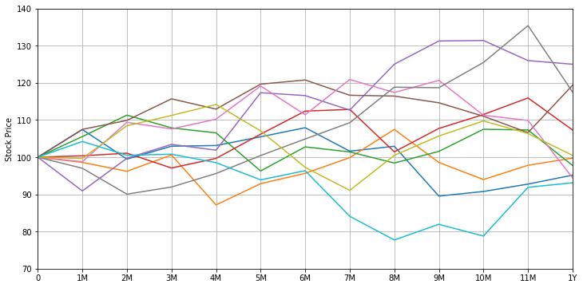

```python
ts = np.linspace(0, 1, 13)
npaths = 10000
paths = blackscholes_mc(S, vol, r, q, ts=ts, npaths=npaths)
fig, ax = plt.subplots(figsize=(12, 6))
ax.plot(ts, paths[:, :10])
ax.set_xticks(ts)
ax.set_xticklabels(['0', '1M', '2M', '3M', '4M', '5M', '6M', '7M', '8M', '9M', '10M', '11M', '1Y'])
ax.set_ylabel('Stock Price')
ax.grid(True)
```

### Price of European put option

```python
np.mean(np.maximum(K-paths[-1], 0))*np.exp(-r*T)
```

```
4.309150482654138
```

### Price of Bermudan put option with monthly exercises

#### Longstaff-Schwartz algorithm

We use polynomials as basis functions for demonstration purposes.

```python
payoff = np.maximum(K-paths[-1], 0)
for i in range(len(ts)-2, 0, -1):
    discount = np.exp(-r*(ts[i+1]-ts[i]))
    payoff = payoff*discount
    p = np.polyfit(paths[i], payoff, deg=2)
    contval = np.polyval(p, paths[i])
    exerval = np.maximum(K-paths[i], 0)
    # identify the paths where we should exercise
    ind = exerval > contval
    payoff[ind] = exerval[ind]
np.mean(payoff*np.exp(-r*(ts[1]-ts[0])))
```

```
4.878593085482579
```

#### Tsitsiklis-van Roy algorithm

The price from the TVR algorithm is generally too high because regression errors accumulate in the backward induction.

```python
V = np.maximum(K-paths[-1], 0)
for i in range(len(ts)-2, 0, -1):
    discount = np.exp(-r*(ts[i+1]-ts[i]))
    p = np.polyfit(paths[i], V*discount, deg=2)
    contval = np.polyval(p, paths[i])
    exerval = np.maximum(K-paths[i], 0)
    V = np.maximum(exerval, contval)
np.mean(V)*np.exp(-r*(ts[1]-ts[0]))
```

```
6.28632803063364
```

## Questions

**Question 2.1**. Adapt the Longstaff-Schwartz and TVR code to use different regression methods:

**(a).** Weighted Laguerre polynomials $\tilde{L}_n$ up to degree 2 as basis functions.  
Note: since the weighted Laguerre polynomials have an exponential term, directly using them may result in numerical underflow. One way to avoid this to renormalize the stock price by the strike price, i.e. regress on $\tilde{L}_n(S/K)$.</li>

**(b).** Black-Scholes put prices.  
Use the constant 1.0 and the Black-Scholes price of a European put option with volatility $\bar\sigma = 0.2$ and maturity $T-t$ as the two basis functions at time $t$. For your convenience, the Black-Scholes pricing formula is included in the cell below.

**(c).** Piecewise Linear regression.

Note: choose the number of knots appropriately in the regression.</li>

**(d).** Kernel regression with Gaussian kernel.

Note: Choose the bandwidth appropriately.</li>

```python
def blackscholes_price(K, T, S, vol, r=0, q=0, callput='call'):
    """Compute the call/put option price in the Black-Scholes model

    Parameters
    ----------
    K: scalar or array_like
        The strike of the option.
    T: scalar or array_like
        The maturity of the option, expressed in years (e.g. 0.25 for 3-month and 2 for 2 years)
    S: scalar or array_like
        The current price of the underlying asset.
    vol: scalar or array_like
        The implied Black-Scholes volatility.
    r: scalar or array_like
        The annualized risk-free interest rate, continuously compounded.
    q: scalar or array_like
        The annualized continuous dividend yield.
    callput: str
        Must be either 'call' or 'put'.

    Returns
    -------
    price: scalar or array_like
        The price of the option.

    Examples
    --------
    >>> blackscholes_price(95, 0.25, 100, 0.2, r=0.05, callput='put')
    1.5342604771222823
    """
    F = S*np.exp((r-q)*T)
    v = np.sqrt(vol**2*T)
    d1 = np.log(F/K)/v + 0.5*v
    d2 = d1 - v
    try:
        opttype = {'call':1, 'put':-1}[callput.lower()]
    except:
        raise ValueError('The value of callput must be either "call" or "put".')
    price = opttype*(F*norm.cdf(opttype*d1)-K*norm.cdf(opttype*d2))*np.exp(-r*T)
    return price
```

#### Q2.1

#### 2.1a

```python
L = lambda x, i: laguerre(i)(x)*np.exp(-x/2)

paths = blackscholes_mc(S, vol, r, q, ts=ts, npaths=npaths)



payoff = np.maximum(K-paths[-1], 0)


for i in range(len(ts)-2, 0, -1):
    discount = np.exp(-r*(ts[i+1]-ts[i]))
    payoff = payoff*discount
    #calculate the matrix A for the least squares regression by evaluating the basis functions at the supports
    #normalized stock prices used
    A = np.vstack((L(paths[i]/K, 0), L(paths[i]/K, 1), L(paths[i]/K, 2))).T
    #calculate the weights for each basis function, vector B, using least squares minimization
    p = np.linalg.lstsq(A, payoff, rcond=None)[0]
    #calculate the continuation value per path using the Laguerre polynomials up to degree 2
    #normalized stock prices used since the least squares problem solved for the normalized stock price
    contval = L(paths[i]/K,0)*p[0]+L(paths[i]/K,1)*p[1]+L(paths[i]/K,2)*p[2]
    exerval = np.maximum(K-paths[i], 0)
    ind = exerval >= contval
    payoff[ind] = exerval[ind]

np.mean(payoff*np.exp(-r*(ts[1]-ts[0])))
```

```
4.952574235888404
```

```python
V = np.maximum(K-paths[-1], 0)
for i in range(len(ts)-2, 0, -1):
    discount = np.exp(-r*(ts[i+1]-ts[i]))
    #calculate the matrix A for the least squares regression by evaluating the basis functions at the supports
    #normalized stock prices used
    A = np.vstack((L(paths[i]/K, 0), L(paths[i]/K, 1), L(paths[i]/K, 2))).T
    #calculate the weights for each basis function, vector B, using least squares minimization
    p = np.linalg.lstsq(A, V*discount, rcond=None)[0]
    #calculate the continuation value per path using the Laguerre polynomials up to degree 2
    #normalized stock prices used since the least squares problem solved for the normalized stock price
    contval = L(paths[i]/K,0)*p[0]+L(paths[i]/K,1)*p[1]+L(paths[i]/K,2)*p[2]
    exerval = np.maximum(K-paths[i], 0)
    V = np.maximum(exerval, contval)

np.mean(V)*np.exp(-r*(ts[1]-ts[0]))
```

```
5.845801348191552
```

#### 2.1b

```python
payoff = np.maximum(K-paths[-1], 0)

for i in range(len(ts)-2, 0, -1):
    discount = np.exp(-r*(ts[i+1]-ts[i]))
    payoff = payoff*discount
    #calculate the matrix A for the least squares regression by evaluating the basis functions at the supports
    A = np.vstack((np.ones_like(paths[i], dtype=np.float),
                   blackscholes_price(K, T - ts[i], paths[i], vol, r, q, callput='put'))).T
    #calculate the weights for each basis function, vector B, using least squares minimization
    p = np.linalg.lstsq(A, payoff, rcond=None)[0]
    #calculate the continuation value per path using the constant 1 and BS put basis functions
    contval = 1 * p[0] + blackscholes_price(K, T - ts[i], paths[i], vol, r, q, callput='put') * p[1]
    exerval = np.maximum(K-paths[i], 0)
    ind = exerval >= contval
    payoff[ind] = exerval[ind]

np.mean(payoff*np.exp(-r*(ts[1]-ts[0])))
```

```
5.094790160125049
```

```python
V = np.maximum(K-paths[-1], 0)
for i in range(len(ts)-2, 0, -1):
    discount = np.exp(-r*(ts[i+1]-ts[i]))
    #calculate the matrix A for the least squares regression by evaluating the basis functions at the supports
    A = np.vstack((np.ones_like(paths[i], dtype=np.float),
                   blackscholes_price(K, T - ts[i], paths[i], vol, r, q, callput='put'))).T
    #calculate the weights for each basis function, vector B, using least squares minimization
    p = np.linalg.lstsq(A, V*discount, rcond=None)[0]
    #calculate the continuation value per path using the constant 1 and BS put basis functions
    contval = 1 * p[0] + blackscholes_price(K, T - ts[i], paths[i], vol, r, q, callput='put') * p[1]
    exerval = np.maximum(K-paths[i], 0)
    V = np.maximum(exerval, contval)

np.mean(V)*np.exp(-r*(ts[1]-ts[0]))
```

```
5.177147580750826
```

#### 2.1c

```python
payoff = np.maximum(K-paths[-1], 0)

for i in range(len(ts)-2, 0, -1):
    discount = np.exp(-r*(ts[i+1]-ts[i]))
    payoff = payoff*discount
    #equally spaced knots based on the support points (current stock prices)
    #using 6 knots as it had good performance without much oscillation in question 1
    xknots = np.linspace(np.percentile(paths[i], 5), np.percentile(paths[i], 95), 6)
    #calculate the weights for each basis function, vector B, using least squares minimization
    #also returns the piecewise functions
    ps, fs = pwlinear_fit(paths[i], payoff, xknots)
    #calculate the continuation value per path using the piecewise linear regression
    contval = sum([f(paths[i])*p for (f, p) in zip(fs, ps)])
    exerval = np.maximum(K-paths[i], 0)
    ind = exerval >= contval
    payoff[ind] = exerval[ind]

np.mean(payoff*np.exp(-r*(ts[1]-ts[0])))
```

```
5.11456018397724
```

```python
V = np.maximum(K-paths[-1], 0)

for i in range(len(ts)-2, 0, -1):
    discount = np.exp(-r*(ts[i+1]-ts[i]))
    #equally spaced knots based on the support points (current stock prices)
    #using 6 knots as it had good performance without much oscillation in question 1
    xknots = np.linspace(np.percentile(paths[i], 5), np.percentile(paths[i], 95), 6)
    #calculate the weights for each basis function, vector B, using least squares minimization
    #also returns the piecewise functions
    ps, fs = pwlinear_fit(paths[i], V*discount, xknots)
    #calculate the continuation value per path using the piecewise linear regression
    contval = sum([f(paths[i])*p for (f, p) in zip(fs, ps)])
    exerval = np.maximum(K-paths[i], 0)
    V = np.maximum(exerval, contval)

np.mean(V)*np.exp(-r*(ts[1]-ts[0]))
```

```
5.107456384517366
```

#### 2d.

```python
payoff = np.maximum(K-paths[-1], 0)
for i in range(len(ts)-2, 0, -1):
    discount = np.exp(-r*(ts[i+1]-ts[i]))
    payoff = payoff*discount
    #calculate the continuation value per path using the NW kernel regression, using the Silverman rule of thumb
    #for the bandwidth
    bw_silverman = (4/(3*len(paths[i])))**0.2*np.std(paths[i])
    contval = kern_reg(paths[i], paths[i], payoff, bw_silverman, gauss_kern)
    exerval = np.maximum(K-paths[i], 0)
    ind = exerval >= contval
    payoff[ind] = exerval[ind]

np.mean(payoff*np.exp(-r*(ts[1]-ts[0])))
```

```
5.1217235423105025
```

```python
V = np.maximum(K-paths[-1], 0)

for i in range(len(ts)-2, 0, -1):
    discount = np.exp(-r*(ts[i+1]-ts[i]))
    #calculate the continuation value per path using the NW kernel regression, using the Silverman rule of thumb
    #for the bandwidth
    bw_silverman = (4/(3*len(paths[i])))**0.2*np.std(paths[i])
    contval = kern_reg(paths[i], paths[i], V*discount, bw_silverman, gauss_kern)
    exerval = np.maximum(K-paths[i], 0)
    V = np.maximum(exerval, contval)

np.mean(V)*np.exp(-r*(ts[1]-ts[0]))
```

```
5.416053984742827
```

**Question 2.2**. Both TVR and Longstaff-Schwartz algorithms provide an estimate for the expected payoff from continuation at each exercise date from the cross-sectional information in the simulation using regression. By comparing this estimate with the immediate exercise value, the holder of the option can determine whether to exercise the option or continue.

Perform an independent Monte Carlo simulation using this estimate of continuation value from **both** algorithms as an exercise policy, and estimate the price of the American put. Explain why this estimate is a lower bound. The basis functions for regression can be chosen to be the quadratic polynomial as in the sample code.

Show your code and result with at least 100000 simulations.

#### Q2.2

In general, both the TVR and LS algorithms are solutions to a primal problem, where the goal is to maximize the expectation of a payoff over all possible stopping times. This is analogous to a 'buyer's price' where the option buyer is attempting to calculate what the maximum possible benefit he may receive from owning the option. Since the numerical algorithms are not 'perfect', they can be considered suboptimal, in that the regressions do not precisely predict the conditional expectations and that there is noise in the simulation paths. This leads to an imperfect calculation of the solution to a primal problem (Snell envelope), and since the optimal strategy is a supremum over stopping times, this implies that a suboptimal strategy must lead to a lower value, and thus a lower bound estimate.

Since the TVR and LS algorithms have issues with high bias, the option value predicted will often be higher than the appropriate option price, especially due to exercise decisions and option value being decided based on future values of the simulation. This means that for a given set of simulated paths, whenever the future values are higher or lower than whatever an 'average' value would be, this information is used to determine the decision to exercise and therefore the 'best' decision is made, leading to an increased valuation for the option.

To avoid this issue, low-biased pricing is used, where the continuation values are estimated in one run of the pricing algorithms, and then an independent run of monte carlo simulations is done in order to evaluate what the option price would be without having opportunities to look into the future. So since the low-biased pricing algorithms lead to lower option values and are solutions to a primal problem, the option values resulting are lower bounds.

```python
npaths = 10000
paths = blackscholes_mc(S, vol, r, q, ts=ts, npaths=npaths)

#set degree of the polynomial regression
degree = 2

#create array that holds coefficients from LS
#the 0th index contains -10000 (any large negative number), since the 0th index stands for the t_Nth
#(final/maturity) date and thus we want to force exercise on that day by having the continuation value lower
#than the exercise value
contvals_LS = -10000.0 * np.ones((degree + 1,), dtype = np.float)


payoff = np.maximum(K-paths[-1], 0)
for i in range(len(ts)-2, 0, -1):

    discount = np.exp(-r*(ts[i+1]-ts[i]))
    payoff = payoff*discount
    p = np.polyfit(paths[i], payoff, deg=degree)
    contval = np.polyval(p, paths[i])
    exerval = np.maximum(K-paths[i], 0)
    ind = exerval >= contval
    payoff[ind] = exerval[ind]

    #add current continuation values to the overall array of continuation values
    contvals_LS = np.vstack((contvals_LS, p))

#create empty array to hold continuation values from TVR
#the 0th index contains -10000 (any large negative number), since the 0th index stands for the t_Nth
#(final/maturity) date and thus we want to force exercise on that day by having the continuation value lower
#than the exercise value
contvals_TVR = -10000.0 * np.ones((degree +1,), dtype = np.float)


V = np.maximum(K-paths[-1], 0)
for i in range(len(ts)-2, 0, -1):

    discount = np.exp(-r*(ts[i+1]-ts[i]))
    p = np.polyfit(paths[i], V*discount, deg=degree)
    contval = np.polyval(p, paths[i])
    exerval = np.maximum(K-paths[i], 0)
    V = np.maximum(exerval, contval)

    #add current continuation values to the overall array of continuation values
    contvals_TVR = np.vstack((contvals_TVR, p))

#flip the arrays so their time order matches that of the paths array
contvals_TVR = np.flip(contvals_TVR, axis = 0 )
contvals_LS = np.flip(contvals_LS, axis = 0 )

#generate 100000 independent new paths for low bias and remove time 0 so it matches our continuation value array
paths = np.delete(blackscholes_mc(S, vol, r, q, ts=ts, npaths=100000),0, axis = 0)

##FOR TVR##
#evaluate the continuation value for each path and time
eval_arr = np.array([np.polyval(contvals_TVR[i], paths[i]) for i in range(0,len(paths))])

#find all locations where continuation value is less than the exercise value
arr = np.array(np.where(eval_arr <= np.maximum(K-paths, 0))).T

#sort the resulting array of indices in ascending order, first by the paths, then by the times the continuation
#value became less than the exercise value. then find the index of the first occurrence of continuation value
#becoming less than the exercise value for each path
_, ind = np.unique(arr[np.lexsort((arr[:,0], arr[:,1]))][:,1], return_index= True)

#go through the lexsorted array and store the locations of the first times continuation value became less
#than exercise value for each path
ind2 = arr[np.lexsort((arr[:,0], arr[:,1]))][ind].T

#calculate the average of the discounted (to time zero) payoffs from using the exercise policy
TVR_value = np.mean((np.exp(-r * (ts[1:] - ts[0]))[:,np.newaxis] * np.maximum(K-paths,0))[ind2[0],ind2[1]])

##FOR LS##
#the below uses exact same procedure as the TVR low bias pricing except using the LS estimates of continuation value
eval_arr = np.array([np.polyval(contvals_LS[i], paths[i]) for i in range(0,len(paths))])

#find all locations where continuation value is less than the exercise value
arr = np.array(np.where(eval_arr <= np.maximum(K-paths, 0))).T

#sort the resulting array of indices in ascending order, first by the paths, then by the times the continuation
#value became less than the exercise value. then find the index of the first occurrence of continuation value
#becoming less than the exercise value for each path
_, ind = np.unique(arr[np.lexsort((arr[:,0], arr[:,1]))][:,1], return_index= True)

#go through the lexsorted array and store the locations of the first times continuation value became less
#than exercise value for each path
ind2 = arr[np.lexsort((arr[:,0], arr[:,1]))][ind].T

#calculate the average of the discounted (to time zero) payoffs from using the exercise policy
LS_value = np.mean((np.exp(-r * (ts[1:] - ts[0]))[:,np.newaxis] * np.maximum(K-paths,0))[ind2[0],ind2[1]])

print("TVR Value = {}".format(TVR_value))
print("LS Value = {}".format(LS_value))
```

```
TVR Value = 4.962974031814991
LS Value = 4.931785358848651
```

**Question 2.3** Oftentimes parametric regressions may not produce globally accurate estimates of continuation values for all possible values of state variables. One approach to improve the accuracy is to run regression only in the region where option is in the money. When the option is out of money, one should always choose to continue, therefore there is no need to estimate the continuation value.

Modify the Longstaff-Schwartz code to implement this improvement.

Show your code and results with the following basis functions:

**(a).** quadratic polynomial basis functions;

**(b).** basis functions given in Question 2.1(b)

For each case, identify and plot the exercise and continuation regions at time $t=0.5$. Comment on the result.

#### 2.3a

##### Using Polynomial

```python
S = 100
vol = 0.2
r = 0.1
q = 0.02
K = 100
T = 1
ts = np.linspace(0, 1, 13)

#generate 10000 paths for the TVR and LS algorithms
npaths = 10000
paths = blackscholes_mc(S, vol, r, q, ts=ts, npaths=npaths)

payoff = np.maximum(K-paths[-1], 0)

for i in range(len(ts)-2, 0, -1):

    #payoff vector calculated as before
    discount = np.exp(-r*(ts[i+1]-ts[i]))
    payoff = payoff*discount

    #exercise values calculated at time t
    exerval = np.maximum(K-paths[i], 0)

    #array of ITM indices
    itm_ind = np.array(np.where(exerval > 0)[0])

    #perform the least squares minimization only on the ITM paths
    p = np.polyfit(paths[i][itm_ind].flatten(), payoff[itm_ind].flatten(), deg=2)

    #calculate continuation and exercise values for only the ITM paths and compare to find sub-indices of ITM paths
    #where exercise occurs
    contval = np.polyval(p, paths[i][itm_ind])
    exerval = np.maximum(K-paths[i][itm_ind], 0)
    ind = exerval >= contval
    indd = np.array(np.where(ind)[0])

    #capture polynomial data for time t = 0.5 and the payoff values
    if i == 6:
        p6_LS = p
        contval6_LS = payoff

    #update discounted cash flows only where exercise occurs at time i
    payoff[itm_ind[indd]] = exerval[ind]



LS_value = np.mean(payoff*np.exp(-r*(ts[1]-ts[0])))


V = np.maximum(K-paths[-1], 0)
for i in range(len(ts)-2, 0, -1):
    discount = np.exp(-r*(ts[i+1]-ts[i]))

    #exercise values calculated at time t
    exerval = np.maximum(K-paths[i], 0)

    #array of ITM indices
    itm_ind = np.array(np.where(exerval > 0)[0])

    #perform the least squares minimization only on the ITM paths
    p = np.polyfit(paths[i][itm_ind].flatten(), discount * V[itm_ind].flatten(), deg=2)

    #calculate continuation and exercise values for only the ITM paths
    contval = np.polyval(p, paths[i][itm_ind])
    exerval = np.maximum(K-paths[i][itm_ind], 0)

    #capture polynomial data for time t = 0.5
    if i == 6:
        p6_TVR = p
        contval6_TVR = V*discount

    #update the option values per path based on the maximum of the exercise and continuation values
    #only for ITM paths
    V[itm_ind] = np.maximum(exerval, contval)

TVR_value = np.mean(V)*np.exp(-r*(ts[1]-ts[0]))


print("TVR Value = {}".format(TVR_value))
print("LS Value = {}".format(LS_value))
```

```
TVR Value = 5.156501643732341
LS Value = 5.096698243946504
```

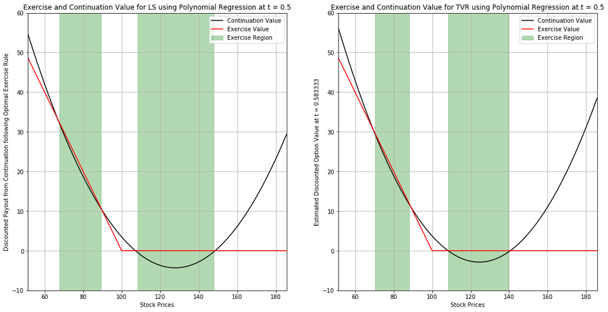

```python
#the following code plots the exercise and continuation values for LS and TVR using polynomial regression
#uncomment the scatter plot lines to see the conditional expectation estimates at time t = 0.5

x = np.linspace(paths[6].min() - 5, paths[6].max() + 5, 1000)

fig, axs = plt.subplots(1,2,figsize=(18, 9))

#axs[0].scatter(paths[6], contval6_LS , alpha=0.6)
axs[0].plot(x, np.polyval(p6_LS, x), 'k', label = 'Continuation Value' )
axs[0].set_title("Exercise and Continuation Value for LS using Polynomial Regression at t = 0.5")
axs[0].set_ylabel("Discounted Payout from Continuation following Optimal Exercise Rule")

#axs[1].scatter(paths[6], contval6_TVR , alpha=0.6)
axs[1].plot(x, np.polyval(p6_TVR, x), 'k', label = 'Continuation Value' )
axs[1].set_title("Exercise and Continuation Value for TVR using Polynomial Regression at t = 0.5")
axs[1].set_ylabel("Estimated Discounted Option Value at t = {:f}".format(ts[7]))

#find exercise vs. continuation regions
x1 = np.linspace(x.min(), x.max(), 100)

for q,f in enumerate([p6_LS, p6_TVR]):
    #array of stock prices where exercise would occur
    arr1 = x1[(np.polyval(f, x1)) <= np.maximum((K -x1), 0)]

    #location of indices where the exercise region changes to continuation or from continuation to exercise
    #this occurs when the difference between stock values at which we'd exercise exceeds some number based on the precision
    #of np.linspace used. I use the average here to be safe.
    li = list(np.where(np.diff(arr1) > np.mean(np.diff(arr1)))[0])

    #the minimum and maximum stock price at which exercise occurs is added to the list of indices
    y = list(itertools.chain(*[(x, x+1) for x in li]))
    y.append(0)
    y.sort()
    y.append(-1)

    #plot the regions
    for i in range(0,len(y),2):
        axs[q].axvspan(arr1[y[i]] , arr1[y[i+1]] ,color='green', alpha=0.3, label = "_"*i + 'Exercise Region')



#plot exercise value
for ax in axs:
    ax.plot(x, np.maximum((K -x), 0), 'r', label='Exercise Value')
    ax.legend(loc=0)
    ax.set_xlim(x.min() , x.max() )
    ax.set_xlabel("Stock Prices")
```

#### 2.3b

##### Using BS Basis Functions

```python
S = 100
vol = 0.2
r = 0.1
q = 0.02
K = 100
T = 1
ts = np.linspace(0, 1, 13)

#generate 10000 paths for the TVR and LS algorithms
npaths = 10000
paths = blackscholes_mc(S, vol, r, q, ts=ts, npaths=npaths)

payoff = np.maximum(K-paths[-1], 0)

for i in range(len(ts)-2, 0, -1):

    #payoff vector calculated as before
    discount = np.exp(-r*(ts[i+1]-ts[i]))
    payoff = payoff*discount

    #exercise values calculated at time t
    exerval = np.maximum(K-paths[i], 0)

    #array of ITM indices
    itm_ind = np.array(np.where(exerval > 0)[0])

    #calculate the matrix A for the least squares regression by evaluating the basis functions at the supports
    #of the ITM paths
    A = np.vstack((np.ones_like(paths[i][itm_ind], dtype=np.float),
                   blackscholes_price(K, T - ts[i], paths[i][itm_ind], vol, r=0, q=0, callput='put'))).T
    #calculate the weights for each basis function, vector B, using least squares minimization
    p = np.linalg.lstsq(A, payoff[itm_ind], rcond=None)[0]

    #calculate continuation and exercise values for only the ITM paths and compare to find sub-indices of ITM paths
    #where exercise occurs
    contval = 1 * p[0] + blackscholes_price(K, T - ts[i], paths[i][itm_ind], vol, r=0, q=0, callput='put') * p[1]
    exerval = np.maximum(K-paths[i][itm_ind], 0)
    ind = exerval >= contval
    indd = np.array(np.where(ind)[0])

    #capture basis function data for time t = 0.5
    if i == 6:
        p6_LS = p
        contval6_LS = payoff

    #update discounted cash flows only where exercise occurs at time i
    payoff[itm_ind[indd]] = exerval[ind]

LS_value = np.mean(payoff*np.exp(-r*(ts[1]-ts[0])))


V = np.maximum(K-paths[-1], 0)
for i in range(len(ts)-2, 0, -1):
    discount = np.exp(-r*(ts[i+1]-ts[i]))

    #exercise values calculated at time t
    exerval = np.maximum(K-paths[i], 0)

    #array of ITM indices
    itm_ind = np.array(np.where(exerval > 0)[0])

    #calculate the matrix A for the least squares regression by evaluating the basis functions at the supports
    #of the ITM paths
    A = np.vstack((np.ones_like(paths[i][itm_ind], dtype=np.float),
                   blackscholes_price(K, T - ts[i], paths[i][itm_ind], vol , r=0, q=0, callput='put'))).T
    #calculate the weights for each basis function, vector B, using least squares minimization
    p = np.linalg.lstsq(A, discount * V[itm_ind], rcond=None)[0]

    #calculate continuation and exercise values for only the ITM paths and compare to find sub-indices of ITM paths
    #where exercise occurs
    contval = 1 * p[0] + blackscholes_price(K, T - ts[i], paths[i][itm_ind], vol, r=0, q=0, callput='put') * p[1]
    exerval = np.maximum(K-paths[i][itm_ind], 0)

    #capture basis function data for time t = 0.5
    if i == 6:
        p6_TVR = p
        contval6_TVR = V*discount


    #update the option values per path based on the maximum of the exercise and continuation values
    #only for ITM paths
    V[itm_ind] = np.maximum(exerval, contval)

TVR_value = np.mean(V)*np.exp(-r*(ts[1]-ts[0]))

print("TVR Value = {}".format(TVR_value))
print("LS Value = {}".format(LS_value))
```

```
TVR Value = 5.203890950161813
LS Value = 5.137103447176494
```

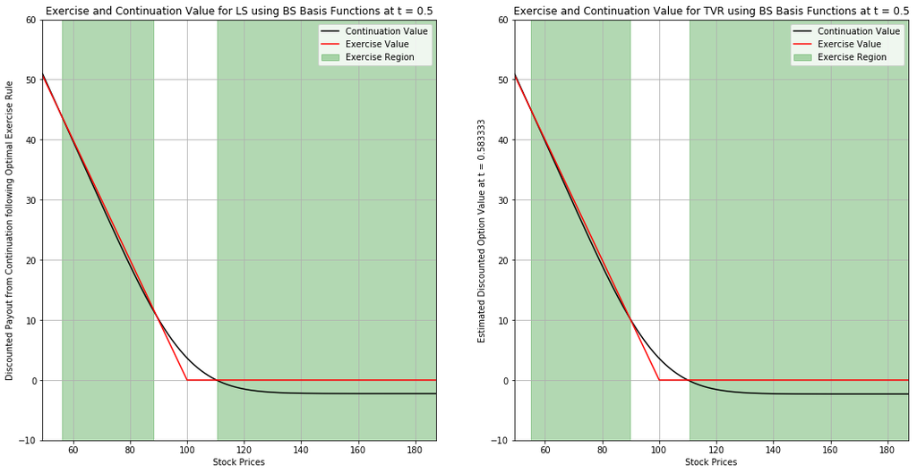

```python
#the following code plots the exercise and continuation values for LS and TVR using BS Basis functions
#uncomment the scatter plot lines to see the conditional expectation estimates at time t = 0.5


x = np.linspace(paths[6].min() - 10, paths[6].max() + 10, 1000)

fig, axs = plt.subplots(1,2,figsize=(18, 9))

#axs[0].scatter(paths[6], contval6_LS , alpha=0.6)
axs[0].plot(x, (1 * p6_LS[0] + blackscholes_price(K, T - ts[6], x, vol=0.2 , r=0, q=0, callput='put') * p6_LS[1]), 'k', label = 'Continuation Value' )
axs[0].set_title("Exercise and Continuation Value for LS using BS Basis Functions at t = 0.5")
axs[0].set_ylabel("Discounted Payout from Continuation following Optimal Exercise Rule")

#axs[1].scatter(paths[6], contval6_TVR , alpha=0.6)
axs[1].plot(x, (1 * p6_TVR[0] + blackscholes_price(K, T - ts[6], x, vol=0.2, r=0, q=0, callput='put') * p6_TVR[1]), 'k', label = 'Continuation Value' )
axs[1].set_title("Exercise and Continuation Value for TVR using BS Basis Functions at t = 0.5")
axs[1].set_ylabel("Estimated Discounted Option Value at t = {:f}".format(ts[7]))


#find exercise vs. continuation regions
x1 = np.linspace(x.min(), x.max(), 100)

for q,f in enumerate([p6_LS, p6_TVR]):
    #array of stock prices where exercise would occur
    arr1 = x1[(1 * f[0] + blackscholes_price(K, T - ts[6], x1, vol = 0.2, r=0, q=0, callput='put') * f[1]) <= np.maximum((K -x1), 0)]

    #location of indices where the exercise region changes to continuation or from continuation to exercise
    #this occurs when the difference between stock values at which we'd exercise exceeds some number based on the precision
    #of np.linspace used. I use the average here to be safe.
    li = list(np.where(np.diff(arr1) > np.mean(np.diff(arr1)))[0])

    #the minimum and maximum stock price at which exercise occurs is added to the list of indices
    y = list(itertools.chain(*[(x, x+1) for x in li]))
    y.append(0)
    y.sort()
    y.append(-1)

    #plot the regions
    for i in range(0,len(y),2):
        axs[q].axvspan(arr1[y[i]] , arr1[y[i+1]] ,color='green', alpha=0.3, label = "_"*i + 'Exercise Region')


for ax in axs:
    ax.plot(x, np.maximum((K -x), 0), 'r', label='Exercise Value')
    ax.legend(loc=0)
    ax.set_xlim(x.min() , x.max() )
    ax.set_xlabel("Stock Prices")
```

For the charts of the exercise regions, I included stock prices in an exercise region as long as the continuation value was $\leq$ to the exercise value, regardless of whether the option was ITM, so for negative continuation values, exercise is indicated. Negative continuation values occurred due to $(K-S)^+$ having minimum value 0 and so ITM continuation values were nearer to low values as stock prices went towards the strike price (this is expected due to the characteristic of the underlying Brownian Motion simulated, and its tendency to not expect large price changes from the present stock value, so a higher current stock price implies a lower option value for the future), and the regressors captured this trend by continuing further below 0 in OTM regions. Since we only used ITM support data points, the regression curves are very inaccurate in OTM regions. This is not an issue in most cases, as continuation values are not necessary to be computed in OTM regions, so we allow for inaccurate regression in the OTM region by design.

In general, when regression was done only using ITM support points, the resulting coefficients for the basis functions across the TVR and LS algorithms, (and therefore the overall output for the regressor at a stock price) were very similar. This effect was seen more heavily the higher the number of paths simulated. This characteristic is due to the discounted payouts (LS) and discounted future option value (TVR) being close for deep ITM options. Since the put price converges to the payoff the further deep in the money the stock price goes, and we only regressed on ITM data points, the resulting regressors for both LS and the TVR algorithms ended up similar regardless of whether the polynomial or BS basis functions were used. This is also seen from the final put prices being closer than in the cases where all data points were used as support points.

In ITM regions both types of regression (polynomial and with the BS basis functions) had similar curves, but the polynomial regression was much worse in the deep OTM regions because of the parabolic shape of degree 2 polynomials.

A result that is hard to see without a visual representation is that there is (depending on the sample paths) a region between extremely deep ITM and ITM-but-closer-to-ATM prices where it would be optimal to exercise (using this algorithm and estimated continuation value). This is not a realistic case since the holder of an American option would have exercised the option by that point (assuming no discontinuous jump in the stock price) since the exercise region occurs before this point.

**Question 2.4**. [Multiple Exercises] Consider a chooser put option that allows its holder to exercise the option up to 3 times among 12 possible monthly exercise dates $t_1=\frac{1}{12}, t_2=\frac{2}{12}, \cdots, t_{12}=1$. If exercised at time $t_i$, the option holder is paid $\left(K-S_{t_i}\right)^+$ with $K=100$. No repetitive exercise at the same exercise date is allowed. The underlying security price is assumed to follow the geometric Brownian motion

$$\frac{dS_t}{S_t}=(r-q)dt+\sigma dW_t$$

with $S_0=100$, $r=0.06$, $q=0.02$ and $\sigma=0.2$.

Note that the standard Bermudan put option can be viewed as a special chooser put option with only one exercise right. Modify the Longstaff-Schwartz algorithm for Bermudan option to price this chooser option.

- For the sake of simplicity, you may use quadratic polynomial basis functions in the regression
- As explained in Question 2.3, the polynomial regression usually give poor global performance. To improve the accuracy, the regression should be done only in the region where option is in the money
- After you have obtained estimations of continuation values from the Longstaff-Schwartz algorithm, run an independent Monte Carlo simulation to obtain a low-biased price, as explained in Question 2.2.

```python
S = 100
vol = 0.2
r = 0.06
q = 0.02
K = 100
T = 1
ts = np.linspace(0, 1, 13)
npaths = 100000
paths = blackscholes_mc(S, vol, r, q, ts=ts, npaths=npaths)
n_T = 3
N= len(ts) - 1
```

```python
#Since the past states on date i can be represented using a vector (x_1, x_2,...,x_{i-1}) where each element is binary
#0 for exercise occurring and 1 for exercise not occurring, we represent the state of the world entering an exercise
#date as a binary number.

#count number of bits in an integer
def popcounter(x):
    return bin(x).count('1')

#lookup table for the states of the world (SOWs) to convert between decimal and binary
popcount = np.vectorize(popcounter)((np.arange(0,2**(N-1))))
```

```python
#create payoff matrix that has each path as a row and each column as a possible state of the world
#since at time i, only SOWs up to (x_1,x_2,...,x_{i-1}) are possible, we need to have 2^(12-1) columns for the
#12th and final day
payoff = np.zeros([len(paths[0]),len(popcount)], dtype = np.float)

#calculate payoff at time N, 0 if no tokens left and the intrinsic value if tokens left
payoff[:,np.where(popcount < n_T)[0]] = np.maximum(K - paths[-1],0)[:,np.newaxis]

#this block of code is for storing the estimated continuation values for the low biased pricing
#matrix to hold coefficients from each time and possible SOW
#order is: coefficient 1 of continuation value, coeff. 2 of continuation value, coeff. 3 of continuation
#coefficient 1 of exercising future value, coefficient 2 of exercising future value, coeff. 3 of exercising future
fcn_matrix = np.full((len(ts) -1, len(popcount), 6), np.nan, dtype = np.float)
#fill in time t_N manually and make sure CF is 0 when all tokens have been used
fcn_matrix[-1,np.where(popcount < n_T)] = [-100000, -100000, -100000, 100000, 1000000, 100000]
fcn_matrix[1:len(ts)-1, np.where(popcount >= n_T)] = [100000, 100000, 100000,-1000000, -100000,-1000000]


#times N-1 to time 2 (inclusive)
for i in range(N-1, 1, -1):

    #the following calculates the current intrinsic value/payoff, the discounted payoff from the SOW such that
    #the option is exercised, and the current estimated option value if the option is exercised
    intrinsic = np.maximum(K - paths[i],0)[:,np.newaxis]
    discounted = np.exp(-r * (ts[i+1] - ts[i])) * payoff[:,np.where(popcount[0:2**(i-1)] <= np.minimum(i-1,n_T-1))[0] + 2**(i-1)]
    exerval = (np.maximum(K - paths[i],0)[:,np.newaxis] + (np.exp(-r * (ts[i+1] - ts[i])) * payoff[:,np.where(popcount[0:2**(i-1)] <= np.minimum(i-1,n_T-1))[0] + 2**(i-1)]))

    #finding ITM indices
    itm = np.where(intrinsic > 0)

    #doing the regression to calculate the conditional expectation for the payoff if exercised
    #then adding the intrinsic value of exercising at present to calculate the total value
    p1 = np.polyfit(paths[i][itm[0]], discounted[itm[0],:], deg=2).T
    contval_2 = np.polynomial.polynomial.polyval(paths[i][itm[0]], np.flip(p1, axis = 1).T).T
    reconstruct = intrinsic[itm[0],:] + contval_2

    #the following calculates the discounted payoff from the SOW such taht the option is not exercised and
    #then performs the regression
    nonexerval = ((payoff[:,np.where(popcount[0:2**(i-1)] <= np.minimum(i-1,n_T-1))[0]]) * np.exp(-r * (ts[i+1] - ts[i])))
    p = np.polyfit(paths[i][itm[0]], nonexerval[itm[0],:], deg=2).T
    contval = np.polynomial.polynomial.polyval(paths[i][itm[0]], np.flip(p, axis = 1).T).T

    #the following updates the payoff matrix based on comparing the value of exercise and value of not exercising
    ind = np.where(reconstruct >= contval)[1]
    ind2 = np.where(reconstruct < contval)[1]
    payoff[itm[0][np.where(reconstruct >= contval)[0]], np.where(popcount[0:2**(i-1)] <= np.minimum(i-1,n_T-1))[0][ind]] = exerval[itm[0][np.where(reconstruct >= contval)[0]],ind]
    payoff[itm[0][np.where(reconstruct < contval)[0]],np.where(popcount[0:2**(i-1)] <= np.minimum(i-1,n_T-1))[0][ind2]] = nonexerval[itm[0][np.where(reconstruct < contval)[0]],ind2]

    #add the current coefficients to the matrix
    fcn_matrix[i-1, np.where(popcount[0:2**(i-1)] <= np.minimum(i-1,n_T-1))[0]] = np.hstack((p,p1))

#time 1
#exact same process as the for loop, but just customized for time 1 since the SOW at time 1 is null since
#no history of exercising could have been possible at time 1
intrinsic_1 = np.maximum(K - paths[1],0)[:,np.newaxis]
discounted_1 = np.exp(-r * (ts[2] - ts[1])) * payoff[:,1][:,np.newaxis]
exerval_1 = (np.maximum(K - paths[1],0)[:,np.newaxis] + (np.exp(-r * (ts[2] - ts[1])) * payoff[:,1][:,np.newaxis]))
itm_1 = np.where(intrinsic_1 > 0)
p1_1 = np.polyfit(paths[1][itm_1[0]], discounted_1[itm_1[0],:], deg=2).T
contval_2_1 = np.polynomial.polynomial.polyval(paths[1][itm_1[0]], np.flip(p1_1, axis = 1).T).T
reconstruct_1 = intrinsic_1[itm_1[0],:] + contval_2_1
nonexerval_1 = payoff[:,0][:,np.newaxis] * np.exp(-r * (ts[2] - ts[1]))
p_1 = np.polyfit(paths[1][itm_1[0]], nonexerval_1[itm_1[0],:], deg=2).T
contval_1 = np.polynomial.polynomial.polyval(paths[1][itm_1[0]], np.flip(p_1, axis = 1).T).T
ind_1 = np.where(reconstruct_1 >= contval_1)[1]
ind2_1 = np.where(reconstruct_1 < contval_1)[1]
payoff[itm_1[0][np.where(reconstruct_1 >= contval_1)[0]], [ind_1]] = exerval_1[itm_1[0][np.where(reconstruct_1 >= contval_1)[0]],ind_1]
payoff[itm_1[0][np.where(reconstruct_1 < contval_1)[0]],[ind2_1]] = nonexerval_1[itm_1[0][np.where(reconstruct_1 < contval_1)[0]],ind2_1]


#Independent runs for low biased pricing
paths = np.delete(blackscholes_mc(S, vol, r, q, ts=ts, npaths=1000000),0, axis = 0)
#create matrices to store the Cash flows and the SOW as the process works forward
SOW_matrix = np.full((len(ts) -1, len(paths[0])), np.nan, dtype = np.int)
CF_matrix = np.full((len(ts) -1, len(paths[0])), 0.0, dtype = np.float)

#need to fill in time 2 SOW and time 1 CF manually
paths_t1 = np.where(np.polynomial.polynomial.polyval(paths[0], np.flip(p_1, axis = 1).T).T <= (np.polynomial.polynomial.polyval(paths[0], np.flip(p1_1, axis = 1).T).T + np.maximum(K - paths[0], 0)[:,np.newaxis]))[0]
CF_matrix[0, paths_t1] = np.maximum(K - paths[0], 0)[paths_t1]
SOW_matrix[1, :] = 0
SOW_matrix[1, paths_t1] = 1

#fill in the CF matrix incrementally
for i in range(1, len(ts)-1):

    #compares the value of exercising vs not exercising
    w1 = np.polynomial.polynomial.polyval(paths[i], np.flip(fcn_matrix[i,:][SOW_matrix[i]][:,0:3], axis = 1).T, tensor = False).T
    w2 = np.polynomial.polynomial.polyval(paths[i], np.flip(fcn_matrix[i,:][SOW_matrix[i]][:,3:6], axis = 1).T, tensor = False).T
    paths_ti = np.where(w1 <= w2 + np.maximum(K-paths[i], 0))

    #update the Cash flow and SOW matrices based on whether exercise occurs or not for all paths
    CF_matrix[i, paths_ti] = np.maximum(K - paths[i], 0)[paths_ti]
    if i != 11:
        SOW_matrix[i+1,:] = SOW_matrix[i,:]
        SOW_matrix[i+1,paths_ti] = SOW_matrix[i+1,paths_ti] + 2**(i)

LS_value = np.mean(np.sum(np.exp(-r * ts[1:])[:,np.newaxis] * CF_matrix, axis = 0))

print("LS Value = {}".format(LS_value))
```

```
LS Value = 17.087454989315354
```

**Question 2.5**. Use the Longstaff-Schwartz algorithm to price an Bermudan-Asian call option. The underlying security price is assumed to follow the geometric Brownian motion

$$\frac{dS_t}{S_t}=(r-q)dt+\sigma dW_t$$

with $S_0=100$, $r=0$, $q=0$ and $\sigma=0.2$. The option has a strike of $K=100$ and a final expiration date of $T=1$ and can be exercised every month before the final maturity, i.e. $$t_1=\frac{1}{12},\, t_2=\frac{2}{12},\, \ldots,\, t_{12}=1$$

The cashflow from exercising the option at time $t_n$, $n=1,\ldots,12$, is $\max\left(0, A_{t_n}-K\right)$ with $A_{t_n}=\frac{1}{n}\sum_{i=1}^nS_{t_i}$.

As the basis functions in the regression at time $t_n$, use the constant 1.0 and the Black-Scholes value of a European call option with strike $K$, maturity $T-t_n$, and volatility $\bar\sigma = 0.1$, written on $$ Z_{t_n}\equiv \frac{nA_{t_n}+(12-n)S_{t_n}}{12} $$

As in Question 2.4, after you have obtained estimations of continuation values from the Longstaff-Schwartz algorithm, run an independent Monte Carlo simulation with at least 100000 paths to obtain a low-biased price. Explain the use of $Z_{t_n}$ instead of simply $A_{t_n}$ or $S_{t_n}$.

$Z_{t_n}$ is used because the Black Scholes value of an European option in the BS model is using a Geometric Brownian Motion. This means that the expected stock price (on non dividend paying stock) at expiration when discounted to the present day (under the risk neutral measure) should be the present stock price. In the case where the interest rate is $0$, this means that the stock price at expiration is expected to be the same as the current stock price. In this sense, when a call option is written on the stock using the BS price, it is implicit that the seller considers the current stock price as a measure of what the stock price may be at expiration.

In the case of the Asian option, the payoff at maturity is not relative to the stock price at maturity, but the average stock price in the 12 months before maturity. So on date $t_n$ the cumulative stock prices thus far is $nA_{t_n}$. From the perspective of the option seller, the option payout at expiration will be the cumulative thus far, plus the remaining amount that accumulates between $t_n$ and maturity. So there are $(12-n)$ months left until maturity, and assuming that the current stock price is expected to stay at its current level (under the risk neutral measure), the expected accumulation by $t_12$ is $nA_{t_n} + (12-n)S_{t_n}$, and so the payout on expiration (as can be best surmised today) would be relative to $Z_{t_n}$ rather than to $S_{t_n}$. So when using the BS value of an European option to try and best predict the conditional expectation of future payoffs for an Asian option, it is as if the European option was written on $Z_{t_n}$ rather than on $S_{t_n}$

#### Regression for all paths

```python
S = 100
vol = 0.2
r = 0
q = 0
K = 100
T = 1
ts = np.linspace(0, 1, 13)
npaths = 10000
paths = blackscholes_mc(S, vol, r, q, ts=ts, npaths=npaths)

contvals_LS = -10000000.0 * np.ones((2,), dtype = np.float)

payoff = np.maximum(np.average(paths[1:len(ts),:], axis = 0) - K, 0)

for i in range(len(ts)-2, 0, -1):
    discount = np.exp(-r*(ts[i+1]-ts[i]))
    payoff = payoff*discount
    #calculate the matrix A for the least squares regression by evaluating the basis functions at the supports
    A = np.vstack((np.ones_like(paths[i], dtype=np.float),
                   blackscholes_price(K, T - ts[i], (((i * np.average(paths[1:(i+1),:], axis = 0)) + ((12 -i) *paths[i]))/12), vol = 0.1, r=0, q=0, callput='call'))).T
    #calculate the weights for each basis function, vector B, using least squares minimization
    p = np.linalg.lstsq(A, payoff, rcond=None)[0]
    #calculate the continuation value per path using the constant 1 and BS put basis functions
    contval = 1 * p[0] +  blackscholes_price(K, T - ts[i], (((i * np.average(paths[1:(i+1),:], axis = 0)) + ((12 -i) *paths[i]))/12), vol = 0.1, r=0, q=0, callput='call')* p[1]
    exerval = np.maximum(np.average(paths[1:(i+1),:], axis = 0) - K, 0)
    ind = exerval >= contval
    payoff[ind] = exerval[ind]

    #add current continuation values to the overall array of continuation values
    contvals_LS = np.vstack((contvals_LS, p))


#flip the arrays so their time order matches that of the paths array
contvals_LS = np.flip(contvals_LS, axis = 0 )

#generate 100000 independent new paths for low bias and remove time 0 so it matches our continuation value array
paths = np.delete(blackscholes_mc(S, vol, r, q, ts=ts, npaths=100000),0, axis = 0)

##FOR LS##
#the below uses exact same procedure as the TVR low bias pricing except using the LS estimates of continuation value
eval_arr = np.array([((1 * contvals_LS[i][0]) +
                     (blackscholes_price(K, T - ts[i+1], ((((i+1) * np.average(paths[1:(i+2),:], axis = 0)) + ((12 -(i+1)) *paths[i]))/12), vol = 0.1, r=0, q=0, callput='call')* contvals_LS[i][1])) for i in range(0,len(paths))])

#find all locations where continuation value is less than the exercise value
ex_arr = np.maximum((np.cumsum(paths.T, axis = 1).T / np.arange(1,13)[:,np.newaxis]) - K, 0)
arr = np.array(np.where(eval_arr <= ex_arr )).T

#sort the resulting array of indices in ascending order, first by the paths, then by the times the continuation
#value became less than the exercise value. then find the index of the first occurrence of continuation value
#becoming less than the exercise value for each path
_, ind = np.unique(arr[np.lexsort((arr[:,0], arr[:,1]))][:,1], return_index= True)

#go through the lexsorted array and store the locations of the first times continuation value became less
#than exercise value for each path
ind2 = arr[np.lexsort((arr[:,0], arr[:,1]))][ind].T

#calculate the average of the discounted (to time zero) payoffs from using the exercise policy
LS_value = np.mean((np.exp(-r * (ts[1:] - ts[0]))[:,np.newaxis] * np.maximum(K-paths,0))[ind2[0],ind2[1]])

print("LS Value = {}".format(LS_value))
```

```
LS Value = 6.0859291563616615
```

#### Regression for ITM paths only

```python
S = 100
vol = 0.2
r = 0
q = 0
K = 100
T = 1
ts = np.linspace(0, 1, 13)
npaths = 10000
paths = blackscholes_mc(S, vol, r, q, ts=ts, npaths=npaths)

contvals_LS = -10000000.0 * np.ones((2,), dtype = np.float)

payoff = np.maximum(np.average(paths[1:len(ts),:], axis = 0) - K, 0)

for i in range(len(ts)-2, 0, -1):
    discount = np.exp(-r*(ts[i+1]-ts[i]))
    payoff = payoff*discount
    exerval = np.maximum(np.average(paths[1:(i+1),:], axis = 0) - K, 0)
    itm_ind = np.array(np.where(exerval > 0)[0])

    #calculate the matrix A for the least squares regression by evaluating the basis functions at the supports
    A = np.vstack((np.ones_like(paths[i][itm_ind], dtype=np.float),
                   blackscholes_price(K, T - ts[i], (((i * np.average(paths[1:(i+1),[itm_ind]], axis = 0)) + ((12 -i) *paths[i][itm_ind]))/12), vol = 0.1, r=0, q=0, callput='call'))).T
    #calculate the weights for each basis function, vector B, using least squares minimization
    p = np.linalg.lstsq(A, payoff[itm_ind], rcond=None)[0]
    #calculate the continuation value per path using the constant 1 and BS put basis functions
    contval = 1 * p[0] +  blackscholes_price(K, T - ts[i], (((i * np.average(paths[1:(i+1),[itm_ind]], axis = 0)) + ((12 -i) *paths[i][itm_ind]))/12), vol = 0.1, r=0, q=0, callput='call')* p[1]
    exerval = np.maximum(np.average(paths[1:(i+1),[itm_ind]], axis = 0) - K, 0)
    ind = exerval >= contval
    indd = np.array(np.where(ind)[0])
    payoff[itm_ind[indd]] = exerval[ind]

    #add current continuation values to the overall array of continuation values
    contvals_LS = np.vstack((contvals_LS, p))

#flip the arrays so their time order matches that of the paths array
contvals_LS = np.flip(contvals_LS, axis = 0 )

#generate 100000 independent new paths for low bias and remove time 0 so it matches our continuation value array
paths = np.delete(blackscholes_mc(S, vol, r, q, ts=ts, npaths=100000),0, axis = 0)

##FOR LS##
#the below uses exact same procedure as the TVR low bias pricing except using the LS estimates of continuation value
eval_arr = np.array([((1 * contvals_LS[i][0]) +
                     (blackscholes_price(K, T - ts[i+1], ((((i+1) * np.average(paths[1:(i+2),:], axis = 0)) + ((12 -(i+1)) *paths[i]))/12), vol = 0.1, r=0, q=0, callput='call')* contvals_LS[i][1])) for i in range(0,len(paths))])

#find all locations where continuation value is less than the exercise value
ex_arr = np.maximum((np.cumsum(paths.T, axis = 1).T / np.arange(1,13)[:,np.newaxis]) - K, 0)
arr = np.array(np.where(eval_arr <= ex_arr )).T

#sort the resulting array of indices in ascending order, first by the paths, then by the times the continuation
#value became less than the exercise value. then find the index of the first occurrence of continuation value
#becoming less than the exercise value for each path
_, ind = np.unique(arr[np.lexsort((arr[:,0], arr[:,1]))][:,1], return_index= True)

#go through the lexsorted array and store the locations of the first times continuation value became less
#than exercise value for each path
ind2 = arr[np.lexsort((arr[:,0], arr[:,1]))][ind].T

#calculate the average of the discounted (to time zero) payoffs from using the exercise policy
LS_value = np.mean((np.exp(-r * (ts[1:] - ts[0]))[:,np.newaxis] * np.maximum(K-paths,0))[ind2[0],ind2[1]])

print("LS Value = {}".format(LS_value))
```

```
LS Value = 5.598078620249024
```